# Gráficos en R

# ¿Para qué usamos los gráficos?

La principales funciones de los gráficos en el análisis de datos son

- explorar los datos y facilitar su comprensión,
- permitir el descubrimiento de patrones no evidentes, y
- comunicar efectivamente los resultados de los análisis.

# Gráficos en R

Veremos dos paradigmas distintos para la creación de gráficos en R.

- Gráficos creados con el paquete `base`.
- Gráficos creados en base a la gramática de gráficos (*GoG*), usando el paquete `ggplot2`

# Gráficos en `base` R

Los gráficos en `base` R se construyen a partir de datos en vectores y usando funciones específicas en función del gráfico a realizar.

Para ejemplifiar algunas de estas funciones, usaremos el conjunto de datos `mtcars`, que forma de los paquetes básicos de R.

```r
str(mtcars)
```

```
## 'data.frame':    32 obs. of  11 variables:
##  $ mpg : num  21 21 22.8 21.4 18.7 18.1 14.3 24.4 22.8 19.2 ...
##  $ cyl : num  6 6 4 6 8 6 8 4 4 6 ...
##  $ disp: num  160 160 108 258 360 ...
##  $ hp  : num  110 110 93 110 175 105 245 62 95 123 ...
##  $ drat: num  3.9 3.9 3.85 3.08 3.15 2.76 3.21 3.69 3.92 3.92 ...
##  $ wt  : num  2.62 2.88 2.32 3.21 3.44 ...
##  $ qsec: num  16.5 17 18.6 19.4 17 ...
##  $ vs  : num  0 0 1 1 0 1 0 1 1 1 ...
##  $ am  : num  1 1 1 0 0 0 0 0 0 0 ...
##  $ gear: num  4 4 4 3 3 3 3 4 4 4 ...
##  $ carb: num  4 4 1 1 2 1 4 2 2 4 ...
```

```r
head(mtcars, 10)
```

```
##                    mpg cyl  disp  hp drat    wt  qsec vs am gear carb
## Mazda RX4         21.0   6 160.0 110 3.90 2.620 16.46  0  1    4    4
## Mazda RX4 Wag     21.0   6 160.0 110 3.90 2.875 17.02  0  1    4    4
## Datsun 710        22.8   4 108.0  93 3.85 2.320 18.61  1  1    4    1
## Hornet 4 Drive    21.4   6 258.0 110 3.08 3.215 19.44  1  0    3    1
## Hornet Sportabout 18.7   8 360.0 175 3.15 3.440 17.02  0  0    3    2
## Valiant           18.1   6 225.0 105 2.76 3.460 20.22  1  0    3    1
## Duster 360        14.3   8 360.0 245 3.21 3.570 15.84  0  0    3    4
## Merc 240D         24.4   4 146.7  62 3.69 3.190 20.00  1  0    4    2
## Merc 230          22.8   4 140.8  95 3.92 3.150 22.90  1  0    4    2
## Merc 280          19.2   6 167.6 123 3.92 3.440 18.30  1  0    4    4
```

Veremos como crear

- gráficos de dispersión,
- histogramas,
- diagramas de barras, y
- diagramas de caja (*boxplot*)

# Gráficos en `base` R – gráfico de dispersión

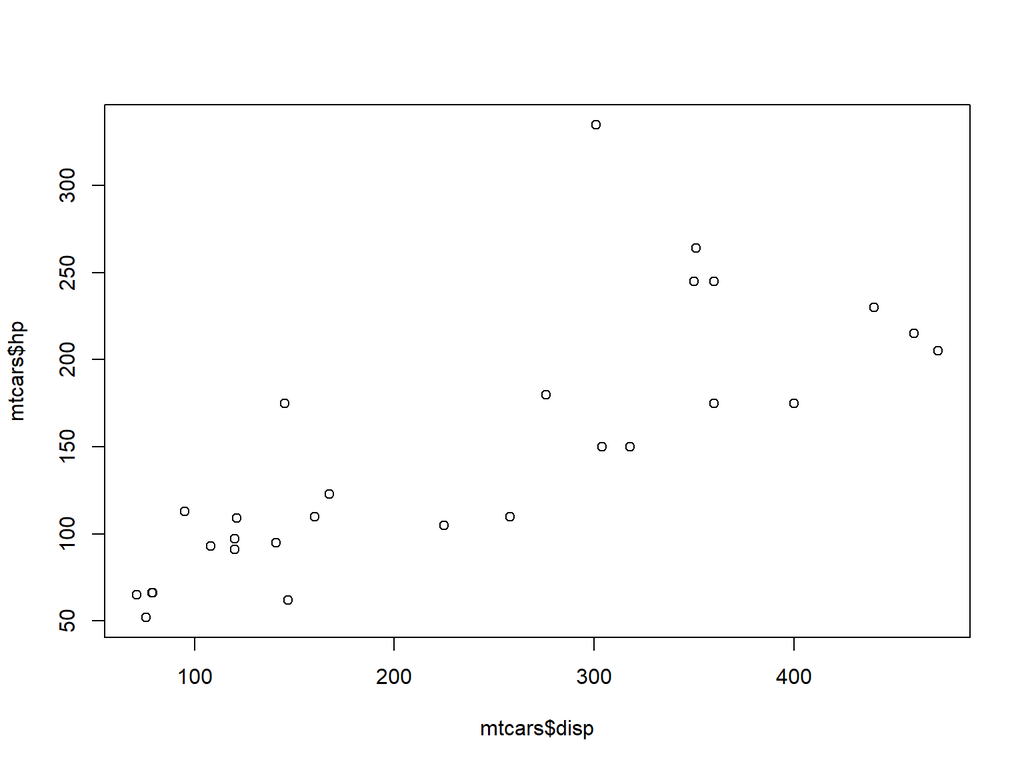

```r
plot(mtcars$disp,mtcars$hp)
```

# Gráficos en `base` R – histograma

```r
hist(mtcars$disp)
```

Añadiendo una curva de densidad…

[figure not shown]

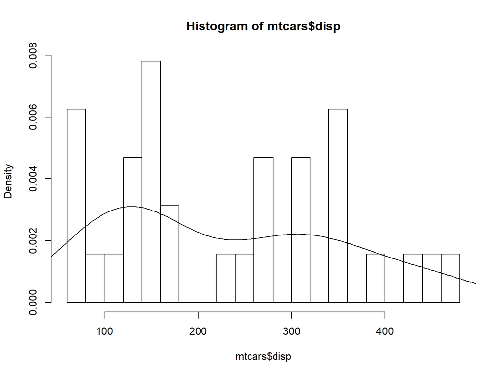

```r
hist(mtcars$disp,breaks=20,freq=FALSE)
lines(density(mtcars$disp))
```

# Gráficos en `base` R – diagrama de barras

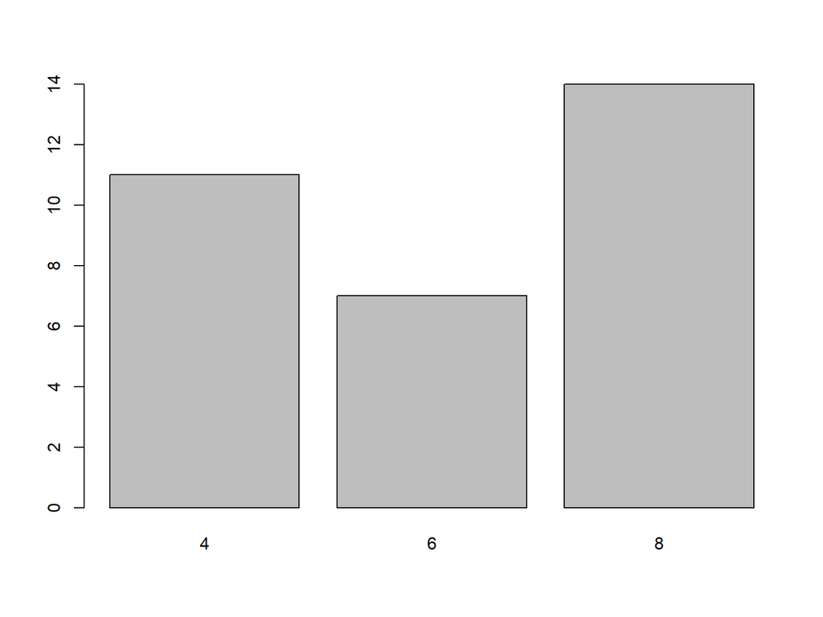

```r
barplot(table(as.factor(mtcars$cyl)))
```

# Gráficos en `base` R – diagrama de caja

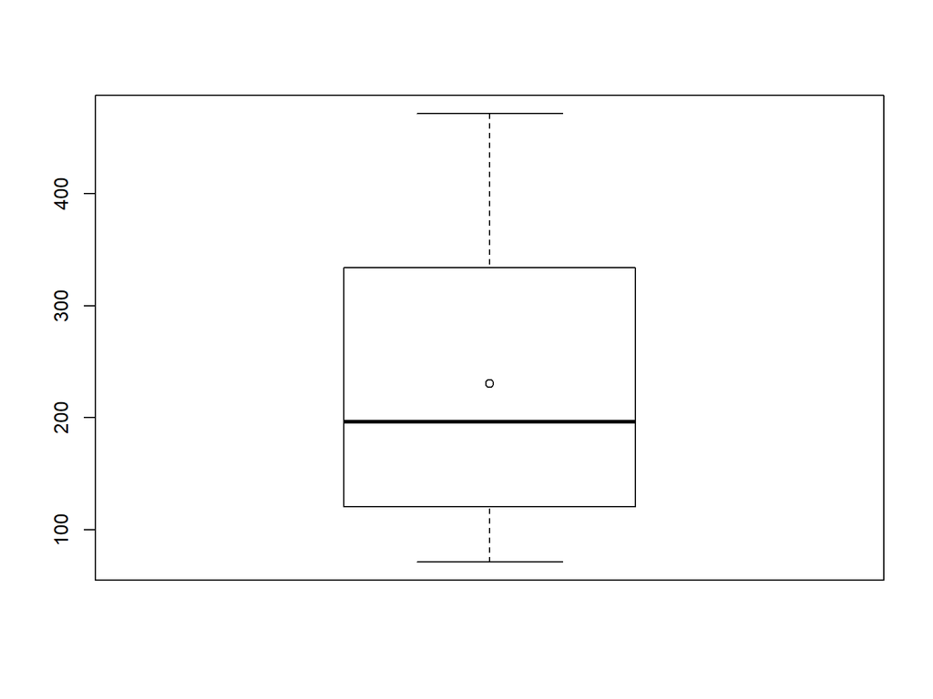

```r
boxplot(mtcars$disp)
points(mean(mtcars$disp))
```

# Gramática de gráficos (*GoG*)

La **gramática de gráficos** es una aproximación teórica al estudio de los componentes de un gráfico. De acuerdo con este análisis, un gráfico se puede construir mediante la especificación de un conjunto de capas y componentes que definen los datos, la asociación de los mismos a aspectos del gráfico, la especificación de la relación entre los valores de las variables de los datos con las del gráfico, la estructura geométrica del gráfico…

Wilkinson, L. (2006). The grammar of graphics. Springer Science & Business Media.

# `ggplot2`

`ggplot2` es un paquete de R que implementa de la gramática de gráficos.

Wickham, H. (2010). A layered grammar of graphics. *Journal of Computational and Graphical Statistics*, 19(1), 3-28.

Referencias:

- http://ggplot2.tidyverse.org/reference/
- https://github.com/rstudio/cheatsheets/raw/master/data-visualization-2.1.pdf
- http://www.ling.upenn.edu/~joseff/avml2012/
- http://r-statistics.co/Complete-Ggplot2-Tutorial-Part1-With-R-Code.html

`ggplot2` forma parte del paquete `tidyverse` (aunque también puede instalarse y cargarse autónomamente).

```r
if(!require("tidyverse")) {
  install.packages("tidyverse")
  library("tidyverse")
}
```

# `ggplot2` – capas y elementos del gráfico

En `ggplot2` cada elemento gráfico que representa un conjunto de datos constituye una capa. Una o más capas constituyen un gráfico.

Cada capa queda definida mediante la especificación de sus elementos. Los principales son

- datos,
- mapeado estético, y
- geometrías

En `ggplot2`, los gráficos constituyen un objeto de R y se construyen de forma aditiva.

Por ejemplo,

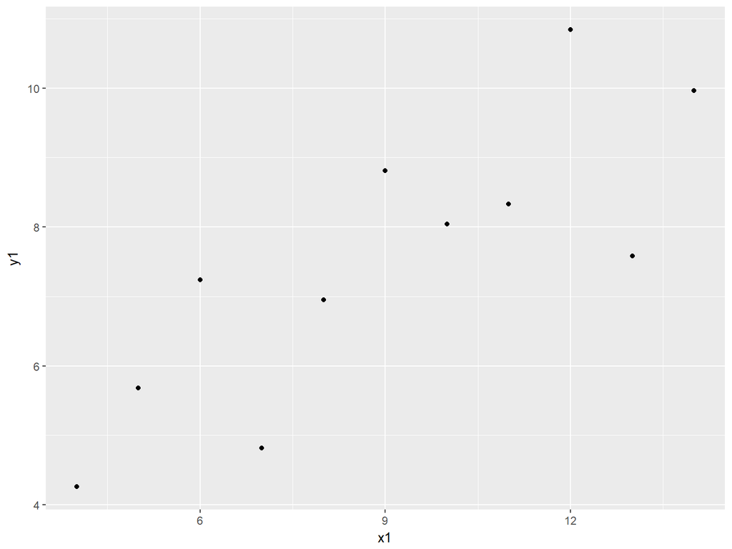

```r
grafico <- ggplot(data = anscombe,
        mapping = aes(x = x1, y = y1))  # Datos y mapeado estético
grafico <- grafico + geom_point()       # Geometría

grafico
```

# `ggplot2` – datos

En `ggplot2`, el elemento `data` (datos) se introduce como primer argumento de la función `ggplot`. Debe corresponder a una tabla de datos o un tipo de datos convertible a tabla de datos.

```r
grafico <- ggplot(data = anscombe,
```

# `ggplot2` – mapeado estético

El `mapping` (mapeado estético) corresponde al establecimiento de relaciones entre variables de los datos y variables del gráfico. Es el segundo argumento de la función `ggplot`y debe crearse con al función de apoyo `aes`.

```r
        mapping = aes(x = x1, y = y1))
```

Para variables cuantitativas, los mapeados más comunes corresponden a

- posiciones: `x`, `y`…
- tamaño: `size`
- color: `color`, `fill`

Para variable cualitativas, los mapeados más frecuentes son

- posiciones: `x`, `y`…
- color: `color`, `fill`
- forma: `shape`

# `ggplot2` – geometrías

Las geometrías (`geom_`) indican la forma que debe tener el gráfico, es decir, cómo se articulan las variables del gráfico. Se añaden al gráfico sumándose al objeto creado por `ggplot`.

```r
grafico <- grafico + geom_point()
```

Son geometrías de uso común

- `geom_point`
- `geom_line`, `geom_vline`, `geom_hline`
- `geom_bar`
- `geom_histogram`
- `geom_boxplot`

Un resumen de las geometrías y su relación con las variables del gráfico que reconoce cada una de ellas figura en https://github.com/rstudio/cheatsheets/raw/master/data-visualization-2.1.pdf.

# Gráficos en `ggplot2`

Veremos cómo crear en `ggplot2` los gráficos más habituales, añadiendo algunas consideraciones para aquellos casos donde los gráficos realizados con `base` tienen prestaciones insuficientes.

- gráficos de dispersión,
- histogramas,
- diagramas de barras, y
- diagramas de caja (*boxplot*).

De forma general, los gráficos en `ggplot2` se construyen a partir de tablas de datos (*data frames*), de los cuales se seleccionan las variables a representar.

Usaremos 1000 datos del conjunto de datos `diamonds` para crear los distintos ejemplos.

```r
diaM <- diamonds[sample(1:nrow(diamonds),1000),]
str(diaM)
```

```
## Classes 'tbl_df', 'tbl' and 'data.frame':    1000 obs. of  10 variables:
##  $ carat  : num  1.01 0.3 1.66 1.5 1.6 1.52 0.35 1 1.08 0.88 ...
##  $ cut    : Ord.factor w/ 5 levels "Fair"<"Good"<..: 1 3 5 5 5 5 5 2 2 1 ...
##  $ color  : Ord.factor w/ 7 levels "D"<"E"<"F"<"G"<..: 1 5 6 5 2 1 1 5 4 3 ...
##  $ clarity: Ord.factor w/ 8 levels "I1"<"SI2"<"SI1"<..: 2 6 4 3 2 4 3 5 2 3 ...
##  $ depth  : num  64.6 63.5 62.3 62 62.7 62.1 61.6 61.8 63.2 56.6 ...
##  $ table  : num  56 55 54 55 53.9 58 55 61 57 65 ...
##  $ price  : int  3003 776 11156 10989 10798 15922 644 5219 4241 2882 ...
##  $ x      : num  6.31 4.28 7.58 7.29 7.43 7.36 4.53 6.4 6.5 6.39 ...
##  $ y      : num  6.24 4.25 7.61 7.34 7.49 7.4 4.56 6.31 6.54 6.32 ...
##  $ z      : num  4.05 2.71 4.73 4.54 4.68 4.58 2.8 3.93 4.12 3.6 ...
```

# Gráficos en `ggplot2` – gráfico de dispersión

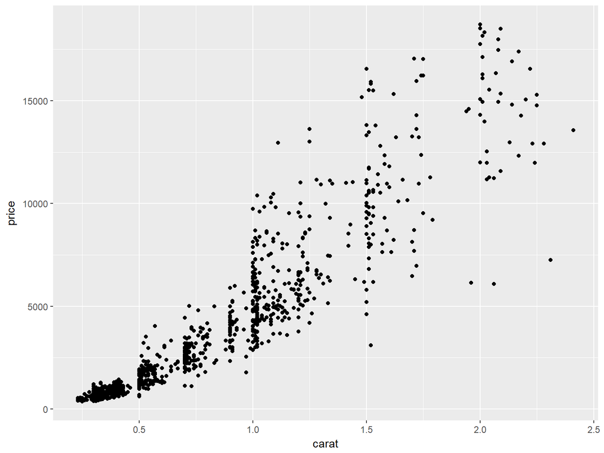

```r
ggplot(diaM, aes(x=carat,y=price)) + geom_point()
```

Añadiendo una tercera variable (`cut`) y modificando algunos aspectos de formato…

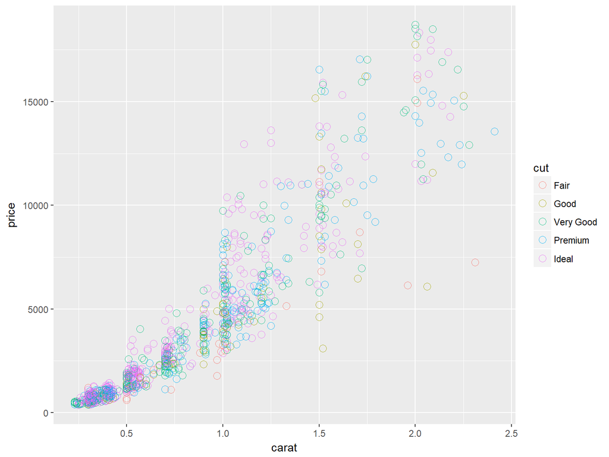

```r
ggplot(diaM, aes(x=carat,y=price,color=cut)) +
  geom_point(alpha=.8,shape=21,size=3)
```

Añadiendo líneas de tendencia…

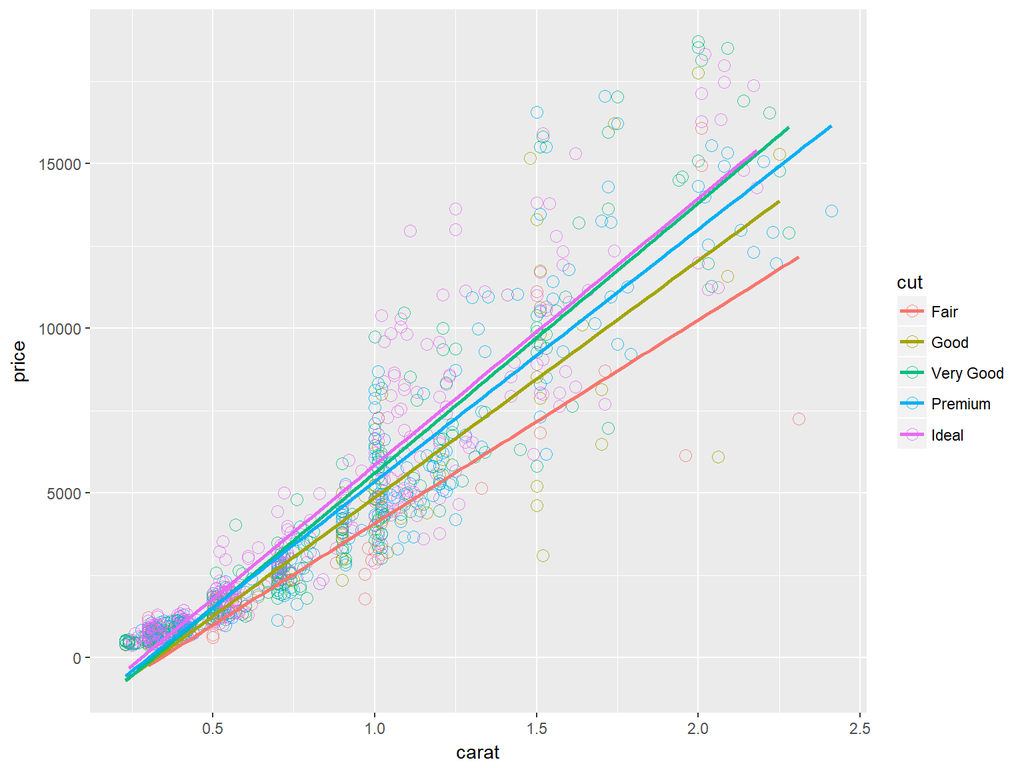

```r
ggplot(diaM, aes(x=carat,y=price,color=cut)) +
  geom_point(alpha=.8,shape=21,size=3) +
  geom_smooth(method="lm",se=FALSE)
```

# Gráficos en `ggplot2` – histograma

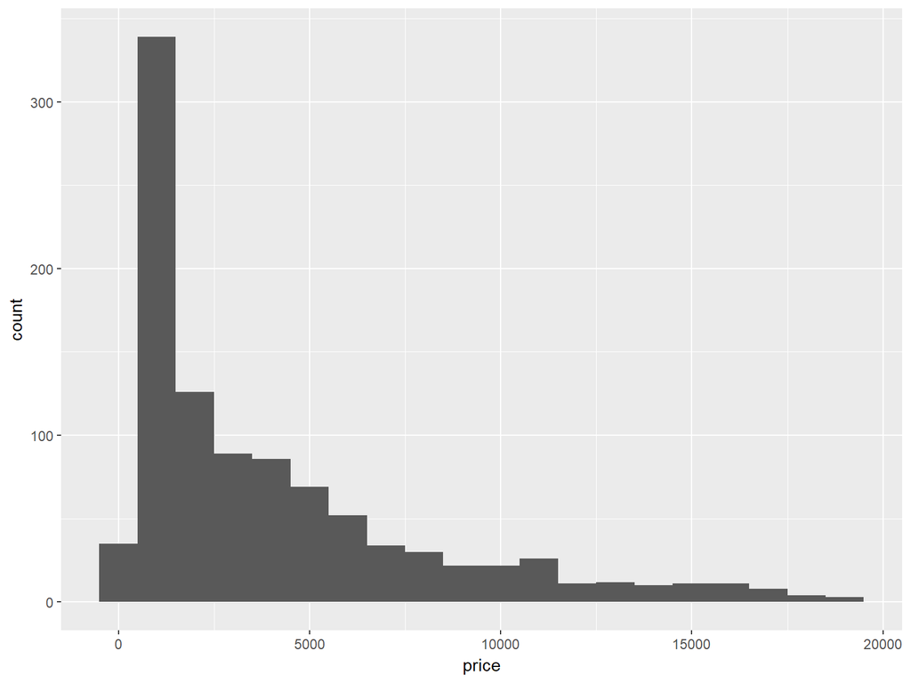

```r
ggplot(diaM, aes(x=price)) + geom_histogram(binwidth=1000)
```

Y en función del corte…

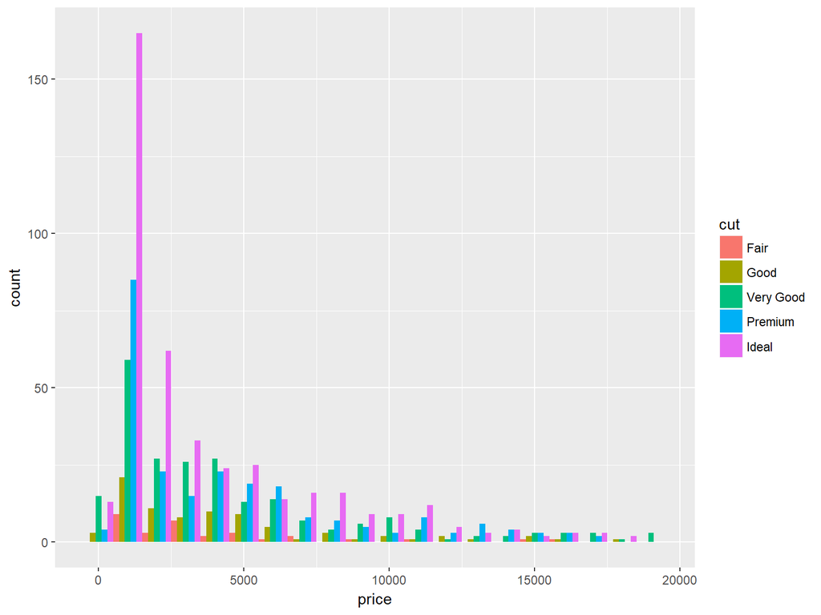

```r
ggplot(diaM, aes(x=price,fill=cut)) +
  geom_histogram(position='dodge',binwidth=1000)
```

En frecuencias relativas (por grupo)…

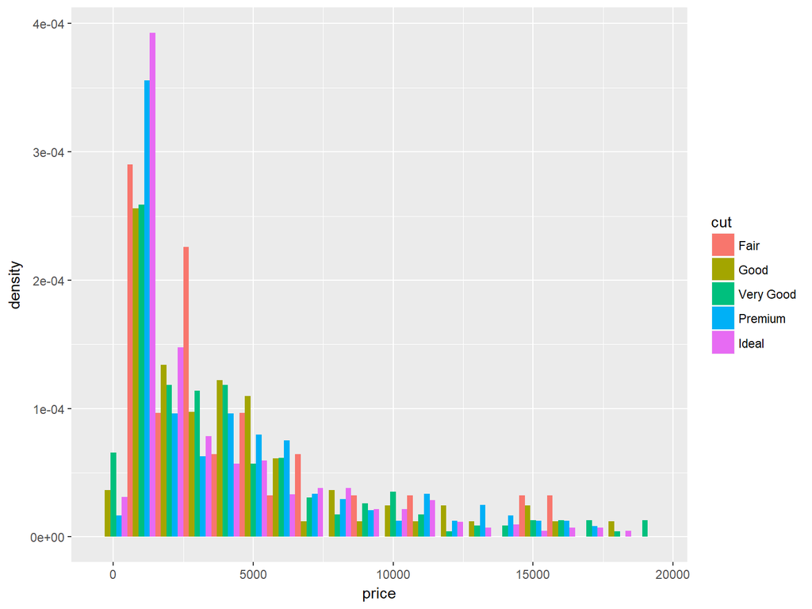

```r
ggplot(diaM, aes(x=price,y=..density..,fill=cut)) +
  geom_histogram(position='dodge',binwidth=1000)
```

Quizás funcione mejor un gráfico de densidades…

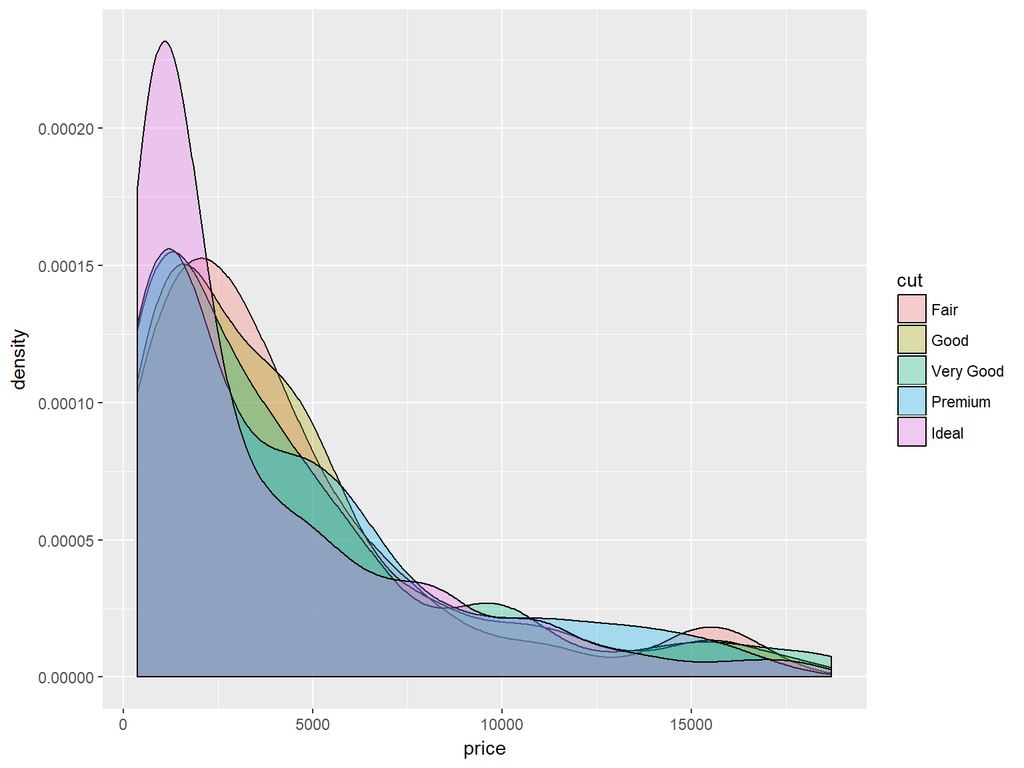

```r
ggplot(diaM, aes(x=price,fill=cut)) +
  geom_density(alpha=.3)
```

# Gráficos en `ggplot2` – diagrama de barras

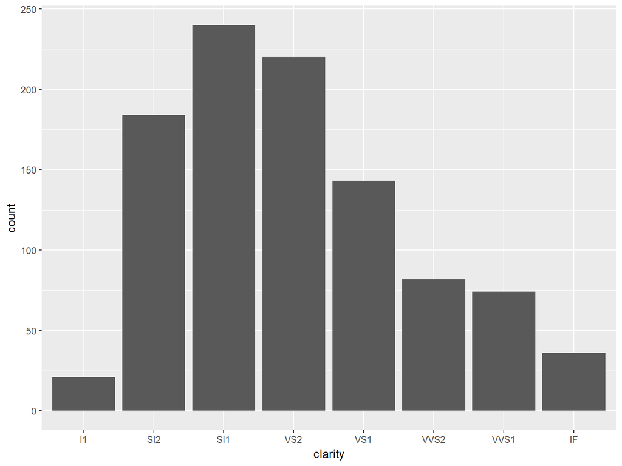

```r
ggplot(diaM, aes(x=clarity)) + geom_bar()
```

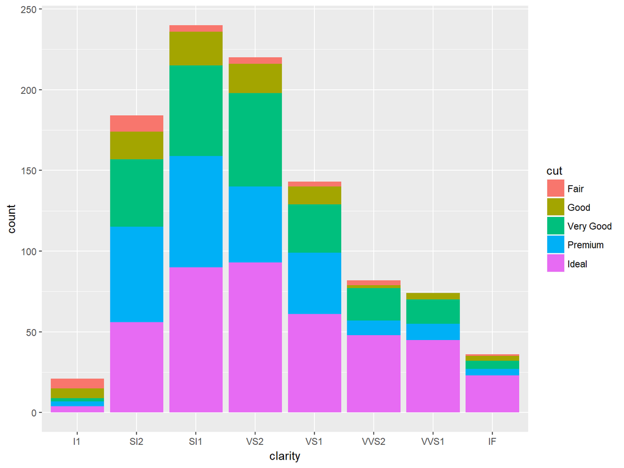

```r
ggplot(diaM, aes(x=clarity, fill=cut)) + geom_bar()
```

Para comparar entre frecuencias absolutas, funcionan mejor las barras separadas.

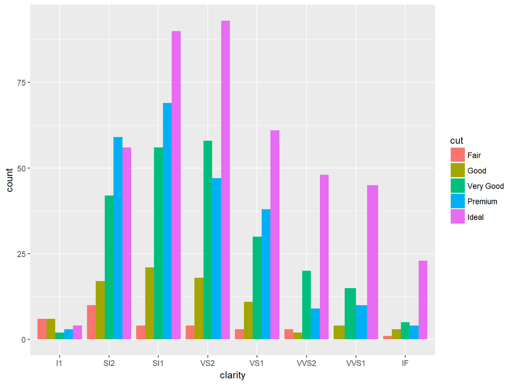

```r
ggplot(diaM, aes(x=clarity, fill=cut)) + geom_bar(position="dodge")
```

Para comparar entre frecuencias relativas acumuladas, son mejores las barras apiladas en frecuencia relativa (para cada clase).

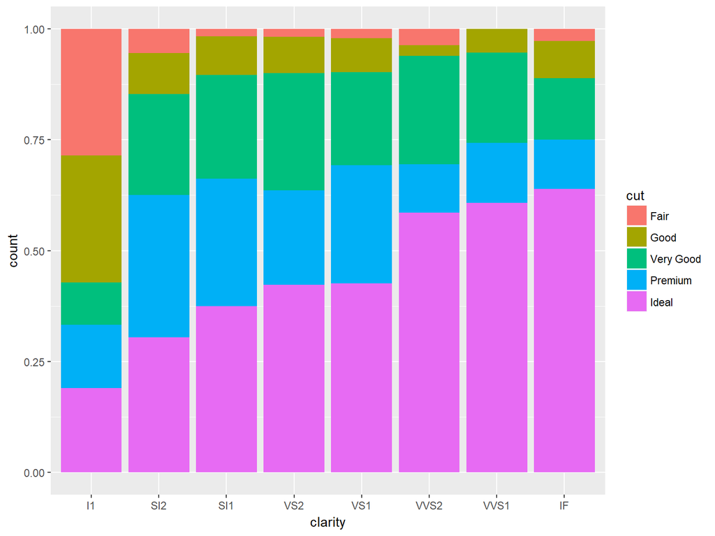

```r
ggplot(diaM, aes(x=clarity, fill=cut)) + geom_bar(position="fill")
```

Los diagramas de barras también pueden crearse a partir de tablas de datos agrupados. En este caso, debe indicarse qué variable es la `y` e incluir `stat="identity"` en el `geom_bar`.

# Gráficos en `ggplot2` – diagrama de caja

```r
ggplot(diaM, aes(x=1, y=price)) + geom_boxplot()
```

*NOTA: Para el `geom_boxplot` se requieren dos variables. Si no hay variable independiente se puede incluir `x=1`.*

[figure not shown]

Y en función del corte…

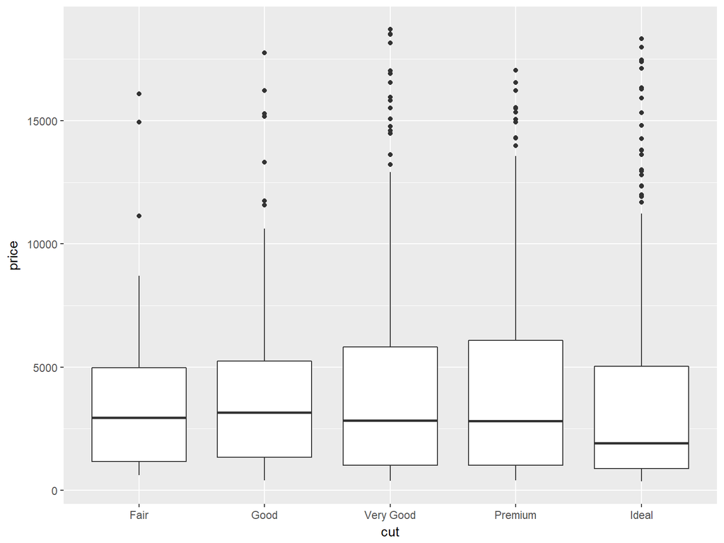

```r
ggplot(diaM, aes(x=cut, y=price)) + geom_boxplot()
```

El gráfico se puede mejorar mostrando todos los puntos, con una posición aleatorizada.

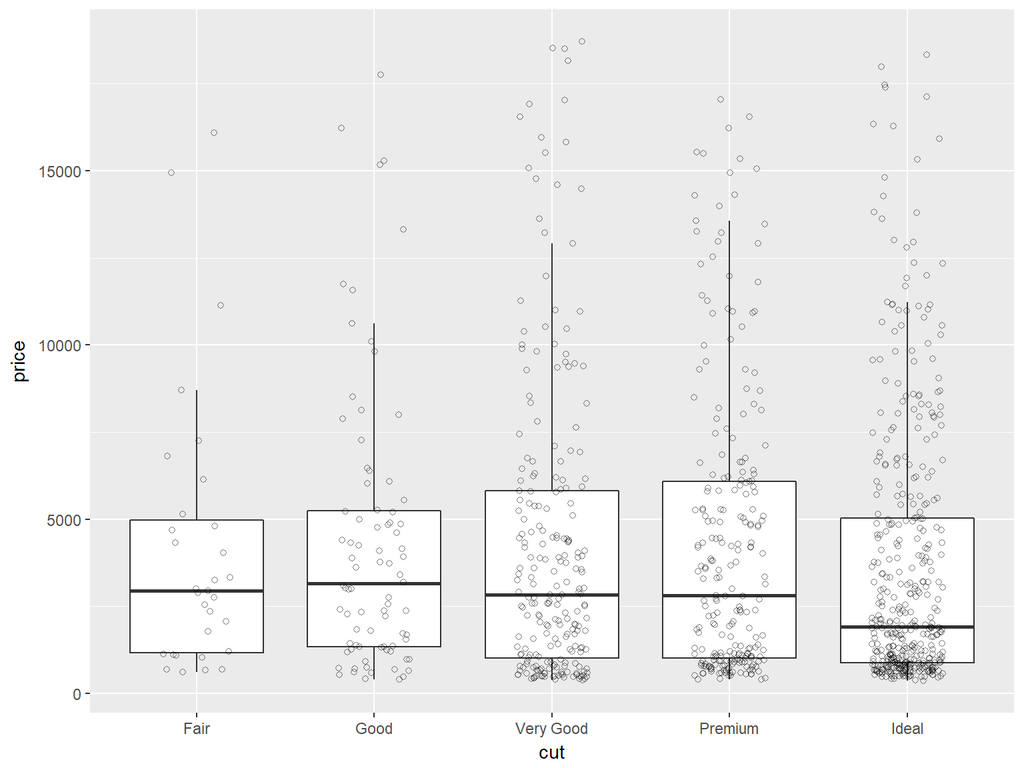

```r
ggplot(diaM, aes(x=cut, y=price)) + geom_boxplot(outlier.shape = NA) +
  geom_jitter(shape = 21, alpha=.5,height=0,width=.2)
```

O incluyendo un *violin plot* y un punto para la media…

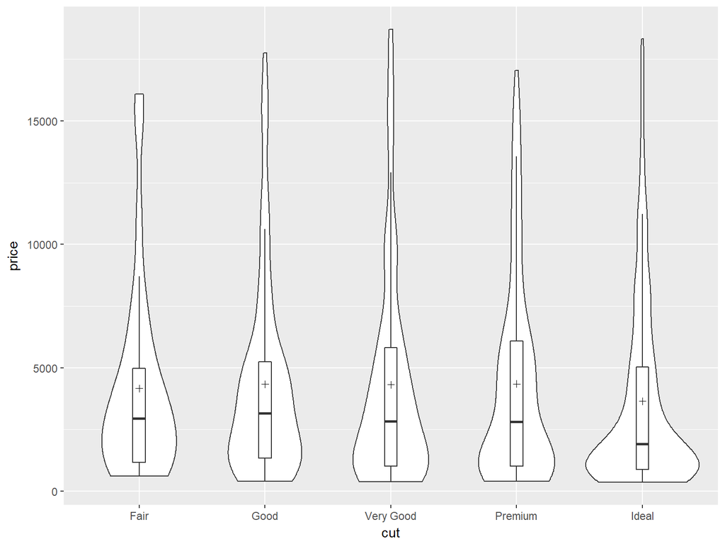

```r
medias <- diaM %>% group_by(cut) %>%
  summarise(price=mean(price))

ggplot(diaM, aes(x=cut, y=price)) +
  geom_violin() +
  geom_boxplot(outlier.shape = NA, width = 0.1) +
  geom_point(data=medias,shape=3)
```

# Estadística básica con R

# Manipulación avanzada de tablas de datos